# Lab 13 WADDS

WADDS

April 18, 2018

## Team

Question Our overall question is “Has sugar intake in grams per person per day increased world wide from since 1961 until 2004?” What we are really asking is, is there a difference in the median amount of sugar consumed per person per day in 1961 versus in 2004? This is an increasingly important question, as many nations such as the United States and the United Kingdom are now facing obesity epidemics. With the Western way of life spreading around the world, this may also soon be affecting countries who are just beginning to see signs of a growing obesity problem, or may not have one yet but could reasonably see problems in the future. Answer this question will help us better humanity in the fight against obesity and health problems. If sugar intake has increased, then focusing on reducing sugar intake could lead to better overall health in the future. If there does not seem evidence that sugar intake has increased, then we are free to explore other variables that may be more useful to fighting obesity in the future.

Null Hypothesis We expect there will not be a difference in sugar intake for countries between the years 1961 and 2004. Therefore, we can predict the average difference in sugar intake will be around 0.

Test Statistic The test statistic we will be using to test our hypothesis will be the median difference in sugar intake for countries between the years 1961 and 2004

Distribution of the Data

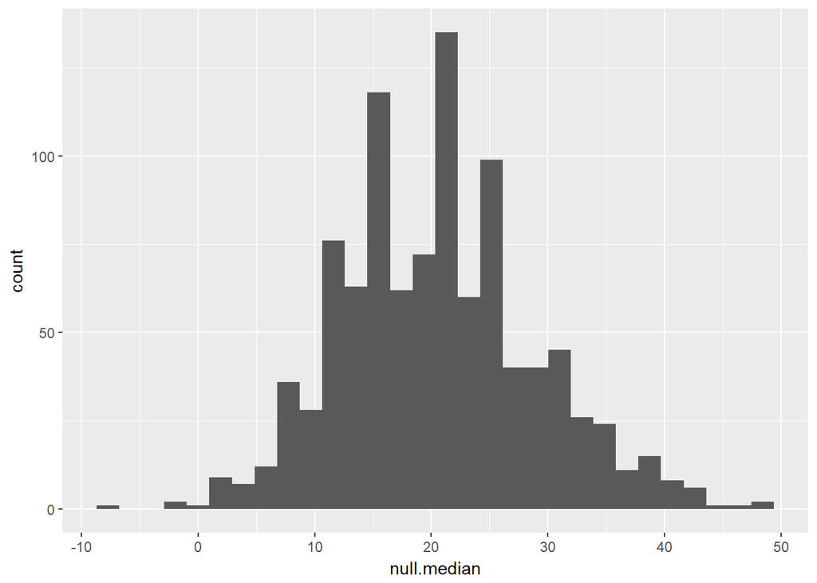

Comparing to the real statistic

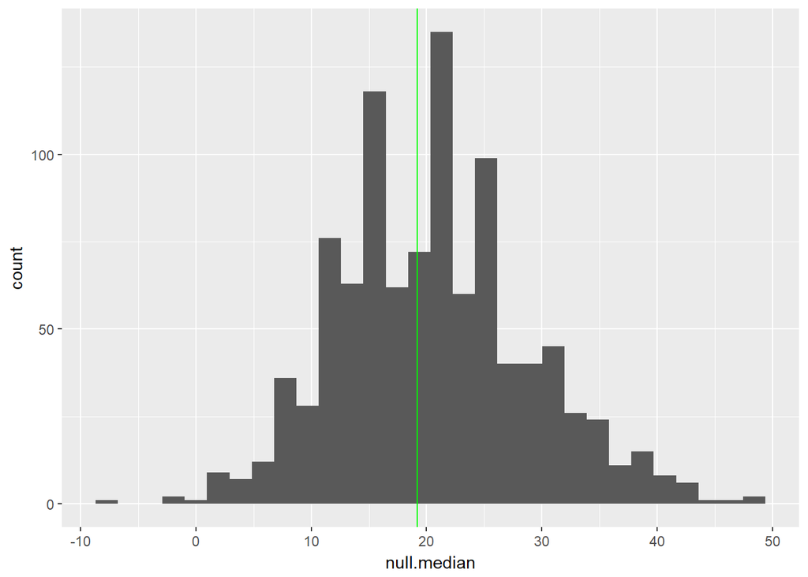

## Abby

Subquestion We want to know if sugar intake increased for every country from 1980 to 1989. If it didn’t, on average, then we would expect the difference between 1980 and 1989 to be around 0. What is the distribution of differences in sugar intake for countries between the years 1980 and 1989.

Null Hypothesis We expect there will not be a difference in sugar intake for countries between the years 1980 and 1989. We expect the average difference in sugar intake to be around 0.

Test Statistic The test statistic for this test will be the median difference in sugar intake between the years 1980 and 1989.

Distribution of the Data

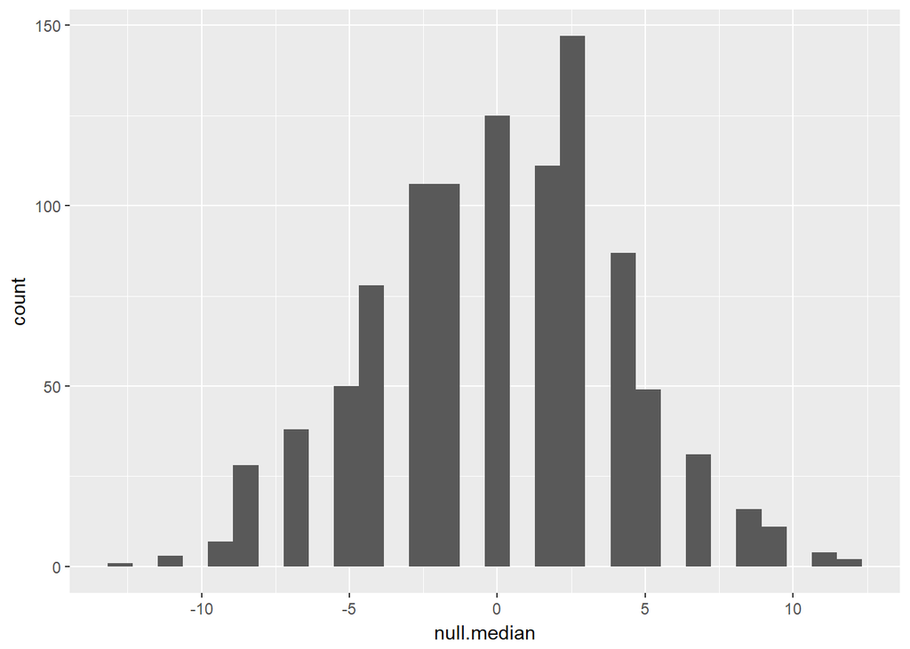

Comparing to the Real Statistic

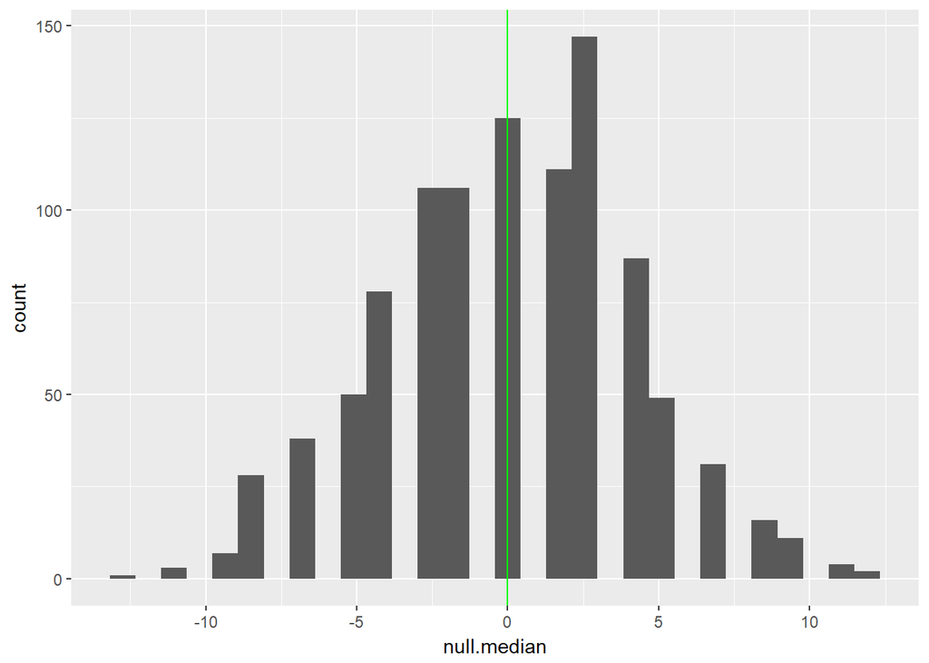

From the plot above we can see visually that our distribution of medians seems to correctly approximate the real median difference in sugar intake between 1980 and 1989. Looking at the percentile of the real median, we see that the real median falls at the 46.4th percentile. Thus, roughly half the differences are less than 0 and roughly half the data is greater than 0. From this, we fail to reject the null hypothesis that there is no difference in sugar intake from 1980 to 1989. Thus, we can conclude that sugar intake did not increase worldwide from 1980 to 1989.

## Derek

Did sugar intake increased globally from 2000 to 2004? If it didn’t, on average, then we would expect the difference between 2000 and 2004 to be around 0.We expect there will not be a difference in sugar intake for countries between the years 2000 and 2004 as the null hypothesis. We expect the average difference in sugar intake to be around 0. The test statistic for this test will be the mean difference in sugar intake between the years 2000 and 2004

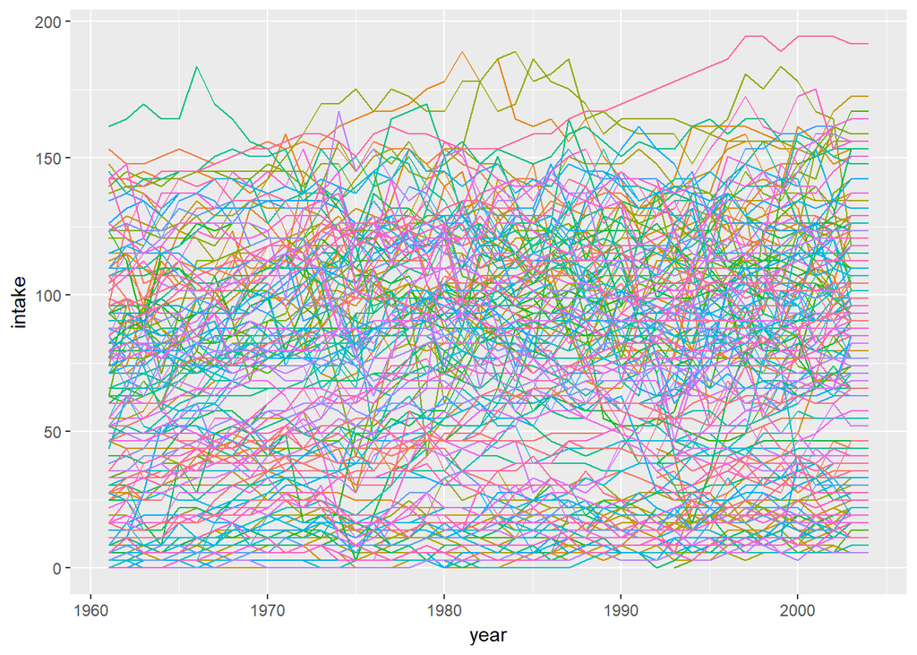

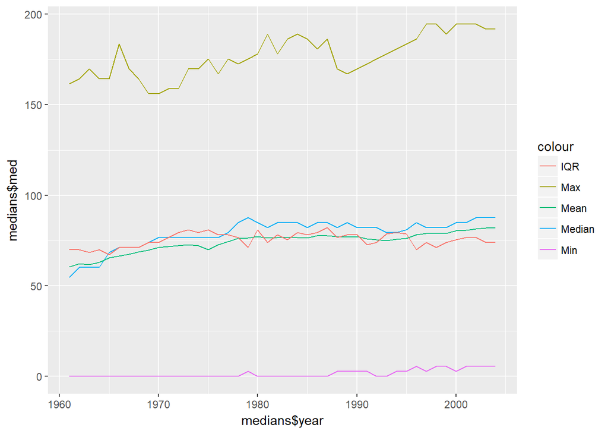

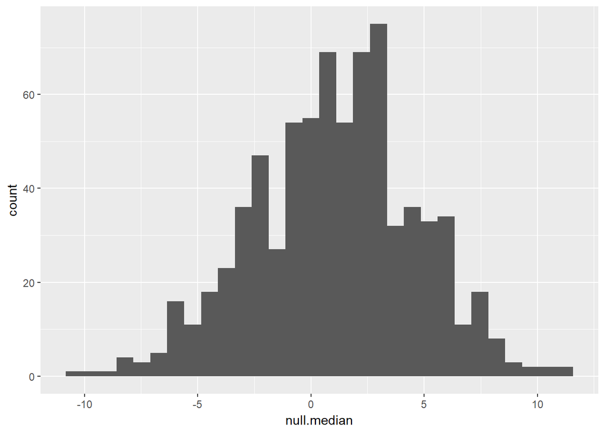

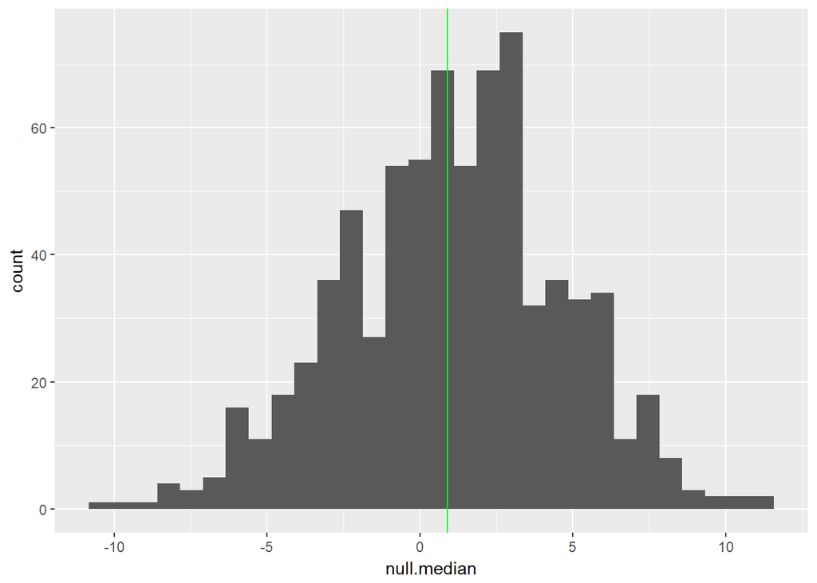

## Sarah

Sugar Consumption Between 1960 an 1970

The question I want to answer is: has there been a significant change in sugar consumption worldwide between 1960 and 1970? This is an important question to answer because it will allow us to gain insight on patterns in how much sugar people are eating all over the world in this decade relative to others and why that might be the case.

The null hypothesis is that there is no significant change in sugar consumption worldwide between 1960 and 1970. The test statistic I will use is the change mean sugar consumption between years. The null hypothesis will be the distribution of the means of sampled sugar consumptions minus the mean of a different sample of sugar consumption, with years and countries unlabeled.

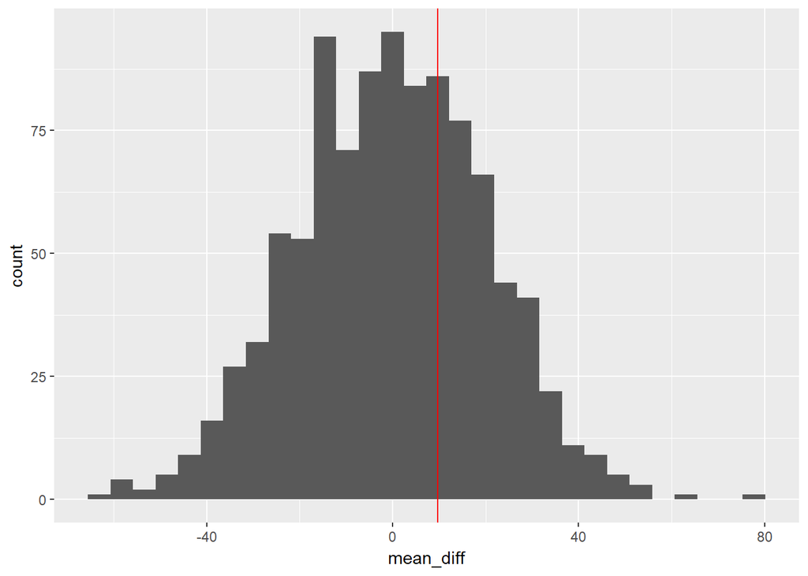

```
## [1] 0.678
```

The difference in mean sugar consumption between 1960 and 1970 represents the 67.8 percentile of the simulated data under our null hypothesis. Therefore, there is no evidence suggesting that the sugar consumption changes worldwide significantly different than in other time periods.

## Will

First Step with the economy develop, it is plausible that the consumption of sugar per person has a significant increase. we will explore whether the consumption of sugar had a significant jump from 70s to 80s. And we will find data-based evidence.

Null Hypothesis. Assume that the averges of consumption of sugar per person over 70s and 80s are equal. Here we take the average consumption over the countries as a proxy of the overall level of the consumption.

Our test statistic, or “summary” of the data is the average consumption of sugar per person 80s subtracted by the one over 70s.

```r
# Reading data from .xlsx file
# sugarConsumption <- gs_url("https://docs.google.com/spreadsheets/d/1IbDM8z5XicMIXgr93FPwjgwoTTKMuyLfzU6cQrGZzH8/pub?gid=0",lookup = FALSE)%>%gs_read(ws = "indicator sugar_consumption", check.names=FALSE)

sugarConsumption_unfilter <- as.tibble(read.csv("sugar_consumption2.csv"))
sugarConsumption <- sugarConsumption_unfilter[!is.na(sugarConsumption_unfilter[,2]),]


# the average consumption of sugar in 70s
sugarConsumption70 <- colMeans(sugarConsumption[,11:20])-> unlist
avg_Consumption70 <- mean(sugarConsumption70)

# the average consumption of sugar in 60s
sugarConsumption80 <- colMeans(sugarConsumption[,21:30])-> unlist
avg_Consumption80 <- mean(sugarConsumption80)
# the real data summary statistic
obsDiff <- avg_Consumption80 - avg_Consumption70
```

Mix Up Now assume that the year labels don’t matter. We mix up the labels, to calculate the test statistic for the mixed-up labels.

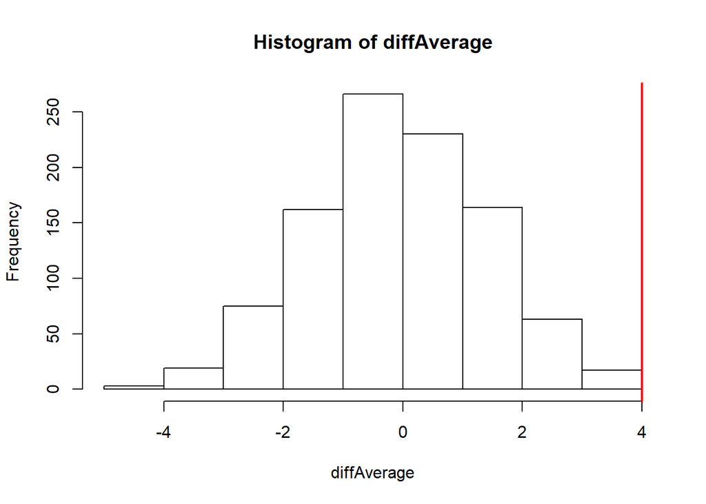

```r
N = 6
diffAverage <- replicate(999, {
    all <- sample(c(sugarConsumption70,sugarConsumption80))
    testGroup1 <- all[1:N]
    testGroup2 <- all[(N+1):(2*N)]
  return(mean(testGroup2) - mean(testGroup1))
})
hist(diffAverage)
abline(v=obsDiff, col="red", lwd=2)
```

The Percentile Now we compare the real data summary statistic with the distribution generated above.

```r
# Find the percentile
percentile <- ecdf(diffAverage)
percentile(obsDiff)
```

```
## [1] 1
```

Conclusion The real data summary statistic is significantly different from the data generated by mixing up the year labels.

So we reject the null hypothesis. That is to say, the consumption of sugar per person had a significant difference between 1970s and 1980s.

## David

Step 1: What is the question? Why is it important/interesting?

My question for this lab is considering whether there is a significant change in sugar consumption worldwide between 1990 and 2000? I think this is interesting because it’s worth for us to know how much sugar does people take for every day. Also we could find out the pattern here.

Step 2: Write down the null hypothesis, which is a statement usually along the lines of âNothing is going on. We expect to see no changes and no effects when considering different variables. Labels do not matter. If you mix them up, nothing will change. Things will always remain boring.

The null hopythesis is that there is no significant change in sugar consumption worldwide between 1990 and 2000. The test statistics here could be the average sugar consumption among years, and the null hypothesis will be the distribution of the average sugar consumption minus average of different sample of sugar consumption

Step 3: Determine your test statistic, or summary of the data.

Step 4. What is the distribution of this statistic according to the null hypothesis? Assume that the year labels don’t matter. Mix up the labels, calculate the test statistic for the mixed-up labels, and store this plausible statistic. Then do it 999 more times. Plot a histogram of this distribution of the mixed-up statistic.

Step 5: How does the real data summary statistic compare to the distribution generated in Step 4? Answer this with a percentile.

```r
c_temp <- sort(unique(data2$X))
ct <- rep(c_temp,44)
mt <- rep(1961:2004,each = 151)
Sugar <- data2[,2]
mydat <- for(i in 2:45){
  Sugar <- c(Sugar,data2[,i])
}
Sugar_con <- Sugar[-c(1:151)]
mydata <- data.frame(Country = ct,year = mt, Sugar_Consumption = Sugar_con)

subdat <- subset(mydata,year == 1990 | year == 2000)
head(subdat)
```

```
##                  Country year Sugar_Consumption
## 4380             Albania 1990             52.06
## 4381             Algeria 1990             82.19
## 4382              Angola 1990             35.62
## 4383 Antigua and Barbuda 1990             87.67
## 4384           Argentina 1990            115.07
## 4385           Australia 1990            136.99
```

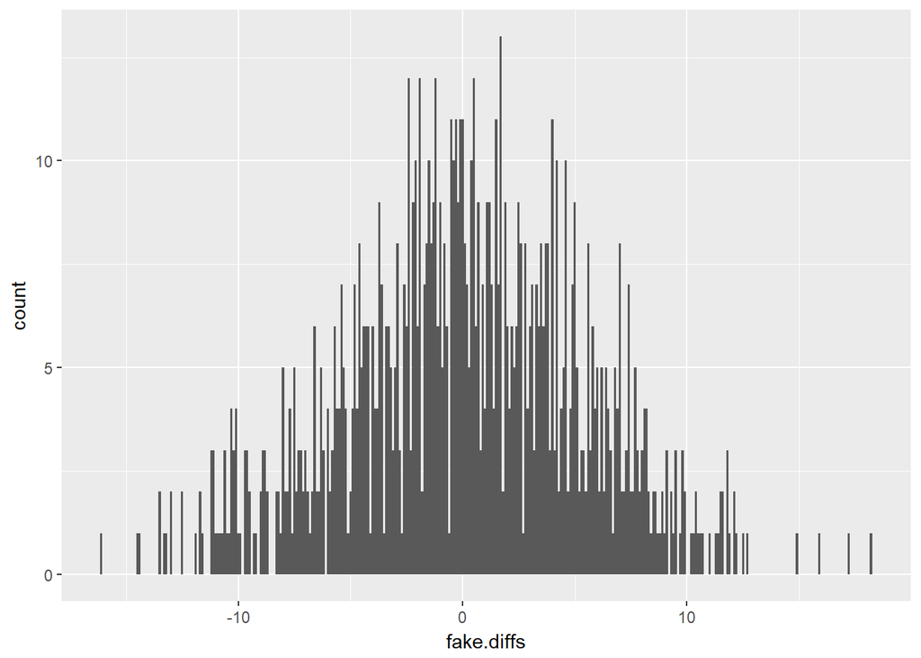

```r
temp <- mean(subdat$Sugar_Consumption)
subdat <- mutate(subdat, abvalerror = abs(Sugar_Consumption-temp))
mean_sugar <- with(subdat,tapply(abvalerror,year,mean))
real.diff <- as.numeric(mean_sugar[2]- mean_sugar[1])

len <- nrow(subdat)
fake.diffs <- vector("double",length=1000)
set.seed(3)
for (i in seq_along(fake.diffs)){
  fake.data <- sample(subdat$Sugar_Consumption,len,replace=F)
  fake.diffs[i] <- mean(fake.data[1:151])-mean(fake.data[152:302])
}
ggplot() +
  geom_histogram(aes(x=fake.diffs),binwidth=0.1)
```

```r
sum(real.diff > fake.diffs)/1000     # 59%
```

```
## [1] 0.59
```

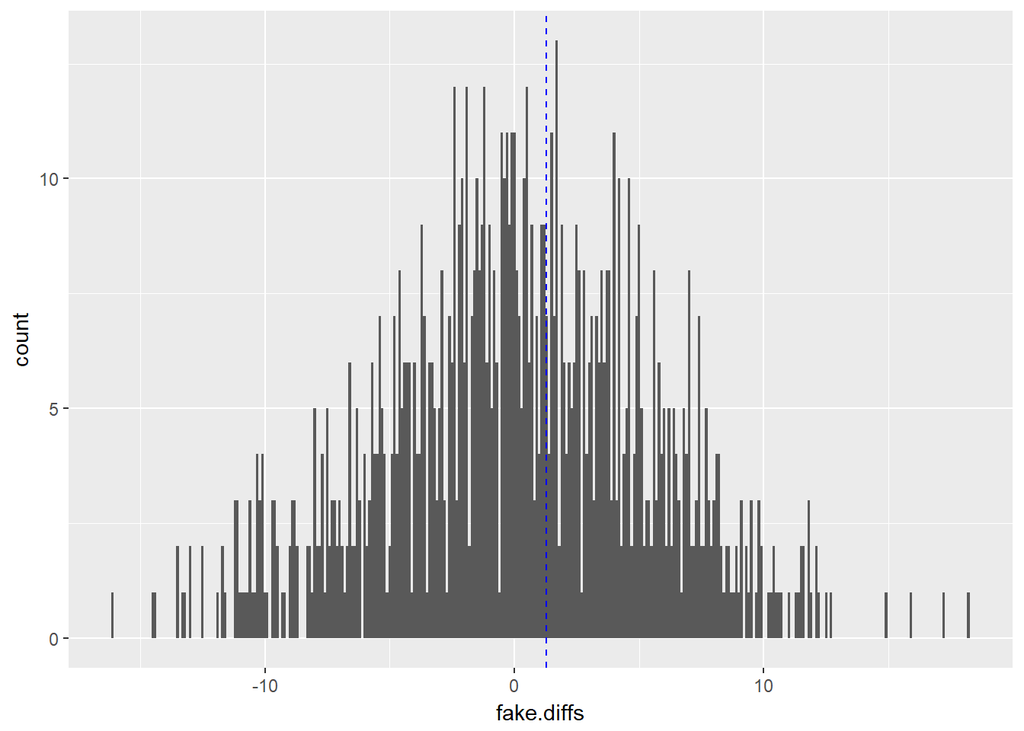

```r
ggplot() +
  geom_histogram(aes(x=fake.diffs),binwidth=0.1) +
  geom_vline(aes(xintercept=real.diff),col="blue",lty=2)
```

Step 6: Make a conclusion about the question you tested in Step 1. Plot the data in a way that shows the data underlying your conclusion.

## Individual Contributions

Abby: I first read in and tidied the data. First, I renamed the column variables to exclude letters from the years and include a label for the country column. Then, I gathered the data by year to reduce the number of columns from 45 to 3 variables. Then, I created a subquestion to help answer our overall question about whether sugar intake has increased worldwide since 1961. I wanted to see if sugar intake had increased during the 1980s, and tested to see if a distribution of sample means would indicate that there was or was not a difference in median sugar intake between 1980 and 1989. Then, I came to the conclusion using my data that sugar intake may not have changed during the 80s, as the test was not significantly difference to indicate otherwise.

Derek: I read in and tidied the data, fixing column names where necessary. I then tested whether the mean consumption of sugar changes from the year 2000 to 2004 and found that it slightly increased. I also created a plot that shows the mean, median, min, max, and IQR for sugar consumption each year globally for our group question.

Sarah: I tested whether there was a significant increase in sugar consumption between 1960 and 1970 relative to the change in cugar consumption overall. I did this by taking the difference in mean sugar consumption overall between 1960 and and 1970 and comparing it with mixed up samples of changes in sugar consumption for all countries and all decades without labels.

Will: For my individual part, I try to analyze the sugar per person fro 1970s to 1980s. I used null hypothesis to analyse it. Firstly, I try to build a histogram for sugar per person. Next, I calculated the differences between it and the probability of it. Fianlly, I got the conclusion that we should reject the null hypothesis. Then it comes with sugar per person had a significant difference between 1970s and 1980s.

David: For this lab we have implemented the function iteration and we have tried to analyze different decades for peopleâs sugar take. I have analyzed between 1990 and 2000. and based on the histogram I have plot, and I have not found out that there is no significiant change between 1990 and 2000.